# 10. ANCOVAs and multiple regression

jsg answers

Last compiled on 05 December, 2022 19:22

Before doing this, review the ** Combining Multiple Explanatory Variables in Linear Models** lecture set slides from https://sites.google.com/view/biostats/lessons/ancova-and-multiple-regression and the **10_ANCOVA_and_Regression.R** script in the lecture files folder of the [CUNY-BioStats github repository](https://github.com/jsgosnell/CUNY-BioStats). Make sure you are comfortable with null and alternative hypotheses and appropriate plots for all examples.

Remember you should

- add code chunks by clicking the *Insert Chunk* button on the toolbar or by pressing *Ctrl+Alt+I* to answer the questions!
- **knit** your file to produce a markdown version that you can see!
- save your work often
  - **commit** it via git!
  - **push** updates to github

## Example

Following the iris example from class

```r
set.seed(13)
iris_example_species <-data.frame(
  Species = c(rep("x",25), rep("y", 25), rep("z", 25)),
  Sepal_Length = runif(75,2,4 ),
  #no difference based on species or sepal length
  Petal_no_impacts = runif (75, 4, 6))
#no difference based on species
iris_example_species$Petal_no_impact_species <-
  iris_example_species$Sepal_Length * 2 + rnorm(75)
#no impact of petal length
iris_example_species$Petal_no_relationship <-rnorm(75) +
  c(rep(2,25), rep(3,25), rep(4,25))
#impact of species and petal length but no interaction
iris_example_species$Petal_no_interaction <-
  iris_example_species$Sepal_Length * 2 + rnorm(75) +
  c(rep(2,25), rep(3,25), rep(4,25))
#impact of species and petal length with interaction
iris_example_species$Petal_interaction <-
  iris_example_species$Sepal_Length * c(rep(-2, 25),rep(2,25), rep(5,25)) +
  c(rep(2,25), rep(3,25), rep(4,25)) + rnorm(75)
```

Plot the data

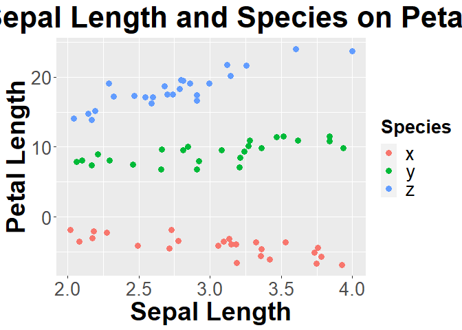

```r
library(ggplot2)
ggplot(iris_example_species, aes(x= Sepal_Length, y = Petal_interaction, color = Species)) +
  geom_point(size = 3)+
  xlab("Sepal Length") +
  ylab("Petal Length") +
  ggtitle("Impact of Sepal Length and Species on Petal Length") +
  theme(axis.title.x = element_text(face="bold", size=28),
        axis.title.y = element_text(face="bold", size=28),
        axis.text.y  = element_text(size=20),
        axis.text.x  = element_text(size=20),
        legend.text =element_text(size=20),
        legend.title = element_text(size=20, face="bold"),
        plot.title = element_text(hjust = 0.5, face="bold", size=32))
```

Note the impact of sepal length appears to depend on species.

```r
library(car)
Anova(lm(Petal_interaction ~ Sepal_Length * Species, iris_example_species),
      type = "III")
```

```
## Anova Table (Type III tests)
##
## Response: Petal_interaction
##                       Sum Sq Df F value    Pr(>F)
## (Intercept)            2.096  1  1.6503    0.2032
## Sepal_Length          28.875  1 22.7307 1.001e-05 ***
## Species                2.920  2  1.1494    0.3228
## Sepal_Length:Species 159.284  2 62.6954 3.027e-16 ***
## Residuals             87.651 69
## ---
## Signif. codes:  0 '***' 0.001 '**' 0.01 '*' 0.05 '.' 0.1 ' ' 1
```

Interaction is significant, so follow up for each species. this ends in regression!

```r
summary(lm(Petal_interaction ~ Sepal_Length,
         iris_example_species[iris_example_species$Species == "x",]))
```

```
##
## Call:
## lm(formula = Petal_interaction ~ Sepal_Length, data = iris_example_species[iris_example_species$Species ==
##     "x", ])
##
## Residuals:
##     Min      1Q  Median      3Q     Max
## -2.1788 -0.9693  0.2359  0.5302  1.6908
##
## Coefficients:
##              Estimate Std. Error t value Pr(>|t|)
## (Intercept)    1.5724     1.1058   1.422    0.168
## Sepal_Length  -1.8824     0.3567  -5.277 2.35e-05 ***
## ---
## Signif. codes:  0 '***' 0.001 '**' 0.01 '*' 0.05 '.' 0.1 ' ' 1
##
## Residual standard error: 1.018 on 23 degrees of freedom
## Multiple R-squared:  0.5477, Adjusted R-squared:  0.528
## F-statistic: 27.85 on 1 and 23 DF,  p-value: 2.35e-05
```

Significant negative relationship for species x.

```r
summary(lm(Petal_interaction ~ Sepal_Length,
           iris_example_species[iris_example_species$Species == "y",]))
```

```
##
## Call:
## lm(formula = Petal_interaction ~ Sepal_Length, data = iris_example_species[iris_example_species$Species ==
##     "y", ])
##
## Residuals:
##     Min      1Q  Median      3Q     Max
## -2.4904 -0.7587  0.2401  0.8115  1.3829
##
## Coefficients:
##              Estimate Std. Error t value Pr(>|t|)
## (Intercept)    3.7147     1.2584   2.952  0.00715 **
## Sepal_Length   1.8307     0.4127   4.436  0.00019 ***
## ---
## Signif. codes:  0 '***' 0.001 '**' 0.01 '*' 0.05 '.' 0.1 ' ' 1
##
## Residual standard error: 1.142 on 23 degrees of freedom
## Multiple R-squared:  0.4611, Adjusted R-squared:  0.4376
## F-statistic: 19.68 on 1 and 23 DF,  p-value: 0.00019
```

Positive relationship for species y

```r
summary(lm(Petal_interaction ~ Sepal_Length,
           iris_example_species[iris_example_species$Species == "z",]))
```

```
##
## Call:
## lm(formula = Petal_interaction ~ Sepal_Length, data = iris_example_species[iris_example_species$Species ==
##     "z", ])
##
## Residuals:
##     Min      1Q  Median      3Q     Max
## -2.4143 -0.5861 -0.1689  0.7747  3.1415
##
## Coefficients:
##              Estimate Std. Error t value Pr(>|t|)
## (Intercept)    4.0916     1.5034   2.722   0.0122 *
## Sepal_Length   5.1553     0.5402   9.543 1.83e-09 ***
## ---
## Signif. codes:  0 '***' 0.001 '**' 0.01 '*' 0.05 '.' 0.1 ' ' 1
##
## Residual standard error: 1.213 on 23 degrees of freedom
## Multiple R-squared:  0.7984, Adjusted R-squared:  0.7896
## F-statistic: 91.07 on 1 and 23 DF,  p-value: 1.834e-09
```

and z!

## Practice

###1

1. Data on FEV (forced expiratory volume), a measure of lung function, can be found at

http://www.statsci.org/data/general/fev.txt

More information on the dataset is available at

http://www.statsci.org/data/general/fev.html.

Does the impact of age on FEV differ among genders? Consider how your answer to this differs from the previous assignment!

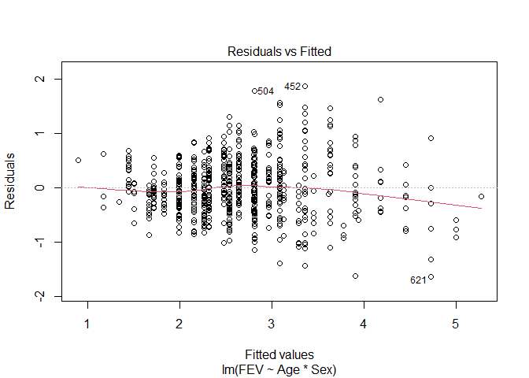

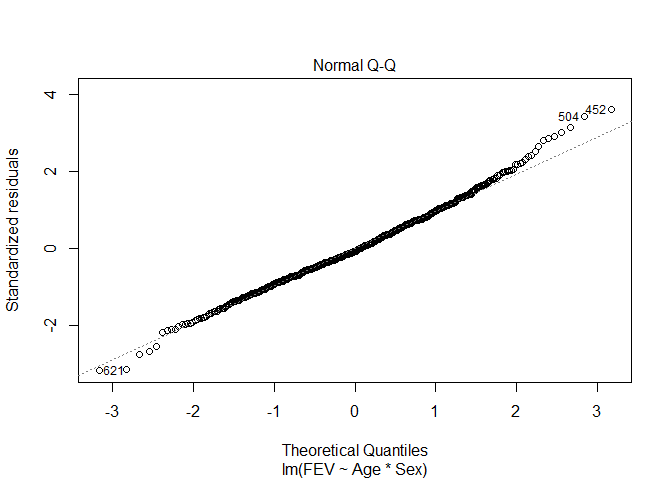

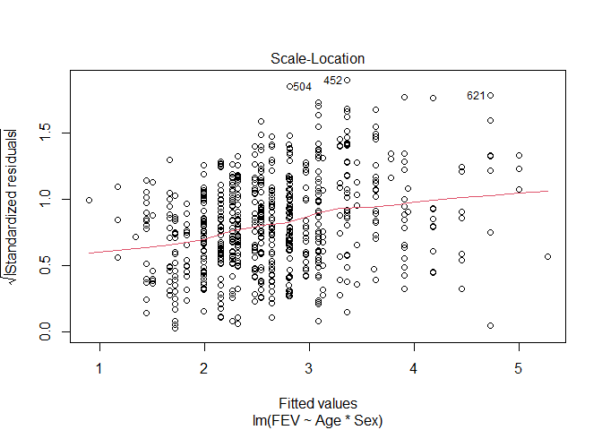

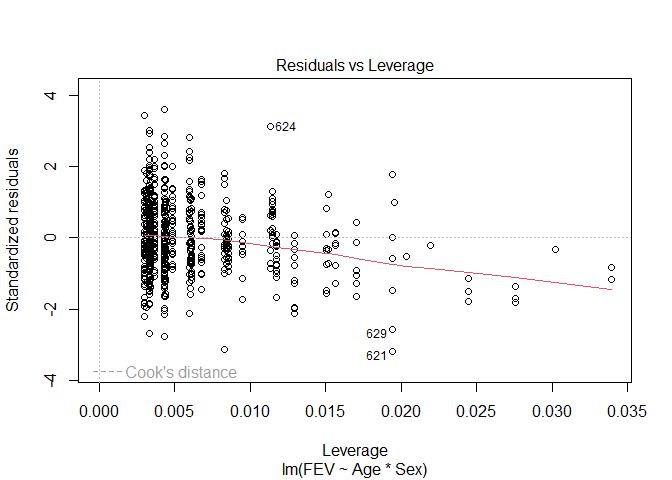

```r
fev <- read.table("http://www.statsci.org/data/general/fev.txt", header = T,
                  stringsAsFactors = T)
fev_age <- lm(FEV ~ Age*Sex, fev)
plot(fev_age)
```

```r
library(car)
Anova(fev_age, type = "III")
```

```
## Anova Table (Type III tests)
##
## Response: FEV
##              Sum Sq  Df F value    Pr(>F)
## (Intercept)  18.654   1  69.087 5.506e-16 ***
## Age          72.190   1 267.356 < 2.2e-16 ***
## Sex           7.977   1  29.543 7.745e-08 ***
## Age:Sex      17.426   1  64.535 4.467e-15 ***
## Residuals   175.509 650
## ---
## Signif. codes:  0 '***' 0.001 '**' 0.01 '*' 0.05 '.' 0.1 ' ' 1
```

```r
summary(fev_age)
```

```
##
## Call:
## lm(formula = FEV ~ Age * Sex, data = fev)
##
## Residuals:
##      Min       1Q   Median       3Q      Max
## -1.64072 -0.34337 -0.04934  0.33206  1.86867
##
## Coefficients:
##              Estimate Std. Error t value Pr(>|t|)
## (Intercept)  0.849467   0.102199   8.312 5.51e-16 ***
## Age          0.162729   0.009952  16.351  < 2e-16 ***
## SexMale     -0.775867   0.142745  -5.435 7.74e-08 ***
## Age:SexMale  0.110749   0.013786   8.033 4.47e-15 ***
## ---
## Signif. codes:  0 '***' 0.001 '**' 0.01 '*' 0.05 '.' 0.1 ' ' 1
##
## Residual standard error: 0.5196 on 650 degrees of freedom
## Multiple R-squared:  0.6425, Adjusted R-squared:  0.6408
## F-statistic: 389.4 on 3 and 650 DF,  p-value: < 2.2e-16
```

*We can explore this question using an ANCOVA since the response is continuous and the explanatory variables combine a categorical and continuous variable. Analysis of residuals indicates the assumptions are met (no pattern, normal distribution). There is a significant interaction among age and gender on FEV (F<sub>1,650</sub>=64.535, p<.001). We should explore impacts of age on each gender separately.*

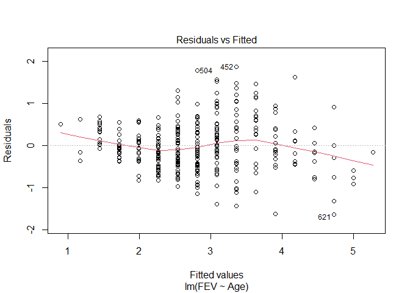

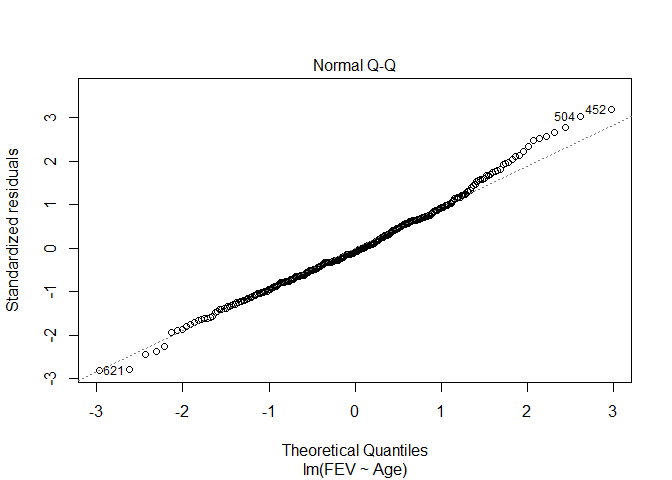

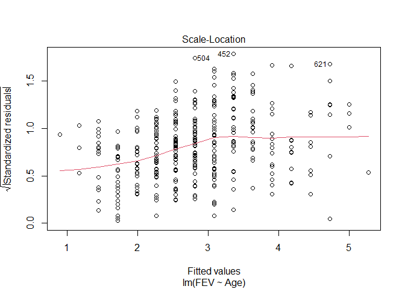

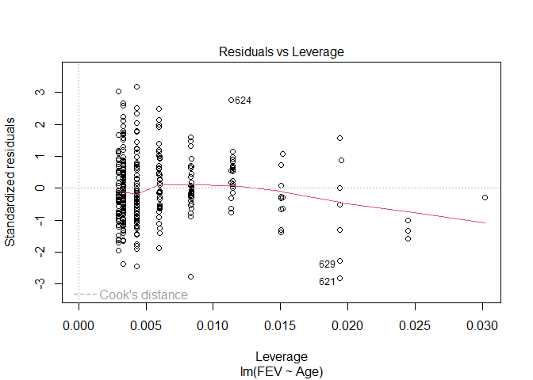

```r
fev_age <- lm(FEV ~ Age, fev[fev$Sex == "Male",])
plot(fev_age)
```

```r
Anova(fev_age, type = "III")
```

```
## Anova Table (Type III tests)
##
## Response: FEV
##              Sum Sq  Df  F value Pr(>F)
## (Intercept)   0.147   1   0.4258 0.5145
## Age         221.896   1 641.5722 <2e-16 ***
## Residuals   115.518 334
## ---
## Signif. codes:  0 '***' 0.001 '**' 0.01 '*' 0.05 '.' 0.1 ' ' 1
```

```r
summary(fev_age)
```

```
##
## Call:
## lm(formula = FEV ~ Age, data = fev[fev$Sex == "Male", ])
##
## Residuals:
##      Min       1Q   Median       3Q      Max
## -1.64072 -0.37752 -0.05318  0.36893  1.86867
##
## Coefficients:
##             Estimate Std. Error t value Pr(>|t|)
## (Intercept)   0.0736     0.1128   0.653    0.514
## Age           0.2735     0.0108  25.329   <2e-16 ***
## ---
## Signif. codes:  0 '***' 0.001 '**' 0.01 '*' 0.05 '.' 0.1 ' ' 1
##
## Residual standard error: 0.5881 on 334 degrees of freedom
## Multiple R-squared:  0.6576, Adjusted R-squared:  0.6566
## F-statistic: 641.6 on 1 and 334 DF,  p-value: < 2.2e-16
```

*Age has a significant (F<sub>1,334</sub> = 641, p < 0.01) positive (.27 L yr<sup>-1</sup>) impact on FEV in males.*

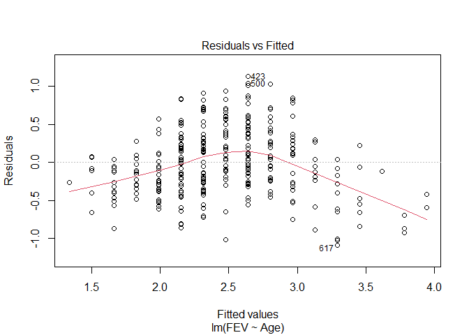

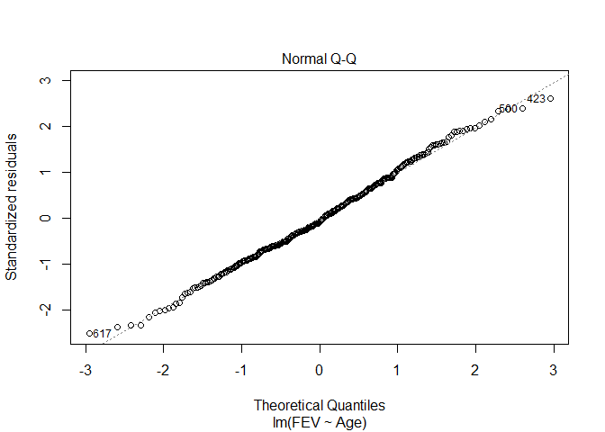

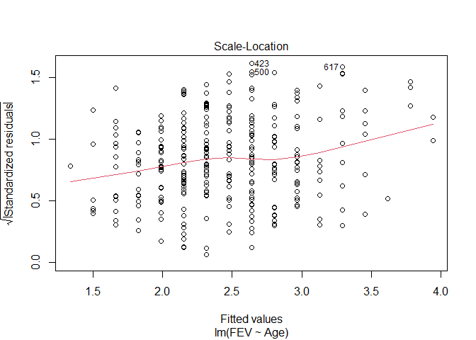

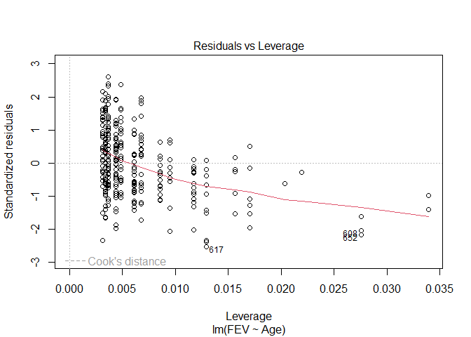

```r
fev_age <- lm(FEV ~ Age, fev[fev$Sex == "Female",])
plot(fev_age)
```

```r
Anova(fev_age, type = "III")
```

```
## Anova Table (Type III tests)
##
## Response: FEV
##             Sum Sq  Df F value    Pr(>F)
## (Intercept) 18.654   1  98.262 < 2.2e-16 ***
## Age         72.190   1 380.258 < 2.2e-16 ***
## Residuals   59.991 316
## ---
## Signif. codes:  0 '***' 0.001 '**' 0.01 '*' 0.05 '.' 0.1 ' ' 1
```

```r
summary(fev_age)
```

```
##
## Call:
## lm(formula = FEV ~ Age, data = fev[fev$Sex == "Female", ])
##
## Residuals:
##      Min       1Q   Median       3Q      Max
## -1.09240 -0.28991 -0.03762  0.28749  1.13451
##
## Coefficients:
##             Estimate Std. Error t value Pr(>|t|)
## (Intercept) 0.849467   0.085695   9.913   <2e-16 ***
## Age         0.162729   0.008345  19.500   <2e-16 ***
## ---
## Signif. codes:  0 '***' 0.001 '**' 0.01 '*' 0.05 '.' 0.1 ' ' 1
##
## Residual standard error: 0.4357 on 316 degrees of freedom
## Multiple R-squared:  0.5461, Adjusted R-squared:  0.5447
## F-statistic: 380.3 on 1 and 316 DF,  p-value: < 2.2e-16
```

*Age also has a significant (F<sub>1,316</sub> = 380, p < 0.01) positive (.16 L yr<sup>-1</sup>) impact on FEV in females. The interaction is likely due to the higher rate of increase of FEV with age in males.*

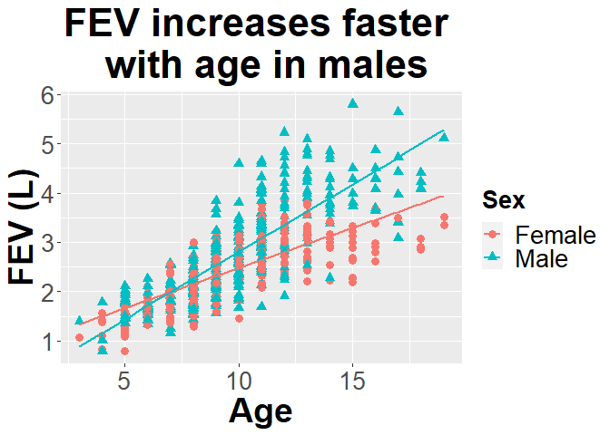

```r
library(ggplot2)
ggplot(fev, aes(x=Age, y=FEV, color = Sex, shape = Sex)) +
  geom_point(size = 3) +
  ylab("FEV (L)") +
  ggtitle("FEV increases faster \n with age in males")+
  theme(axis.title.x = element_text(face="bold", size=28),
        axis.title.y = element_text(face="bold", size=28),
        axis.text.y  = element_text(size=20),
        axis.text.x  = element_text(size=20),
        legend.text =element_text(size=20),
        legend.title = element_text(size=20, face="bold"),
        plot.title = element_text(hjust = 0.5, face="bold", size=32)) +
    geom_smooth(method = "lm", se = F)
```

###2

2. Data on home gas consumption at various temperatures before and after new insulation was installed has been collected @

http://www.statsci.org/data/general/insulgas.txt

More information on the data is available @

http://www.statsci.org/data/general/insulgas.html

Is there any relationship between these factors? How would you test this, and what type of plot would you produce to accompany your analysis?

```r
heat <- read.table("http://www.statsci.org/data/general/insulgas.txt",
                   header = T, stringsAsFactors = T)
head(heat)
```

```
##   Insulate Temp Gas
## 1   Before -0.8 7.2
## 2   Before -0.7 6.9
## 3   Before  0.4 6.4
## 4   Before  2.5 6.0
## 5   Before  2.9 5.8
## 6   Before  3.2 5.8
```

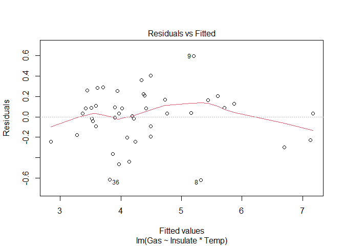

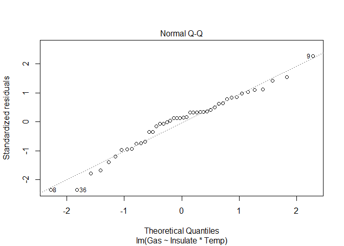

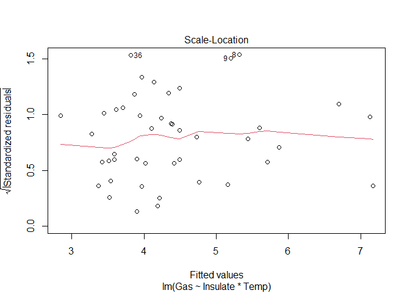

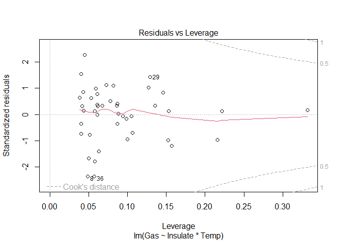

```r
heat_model <- lm(Gas ~ Insulate * Temp, heat)
plot(heat_model)
```

```r
require(car)
Anova(heat_model, type = "III")
```

```
## Anova Table (Type III tests)
##
## Response: Gas
##               Sum Sq Df  F value    Pr(>F)
## (Intercept)   90.636  1 1243.911 < 2.2e-16 ***
## Insulate      12.502  1  171.583 4.709e-16 ***
## Temp           2.783  1   38.191 2.640e-07 ***
## Insulate:Temp  0.757  1   10.391  0.002521 **
## Residuals      2.915 40
## ---
## Signif. codes:  0 '***' 0.001 '**' 0.01 '*' 0.05 '.' 0.1 ' ' 1
```

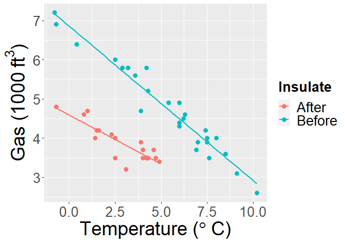

```r
ggplot(heat, aes_string(x="Temp", y="Gas", color = "Insulate")) +
  geom_point(size = 3) +
  ylab(expression(paste("Gas (1000 ",ft^3, ")")))+
  xlab(expression(paste("Temperature (", degree~C, ")")))+
  geom_smooth(method = "lm", se = F) +
  theme(axis.title.x = element_text(face="bold", size=28),
        axis.title.y = element_text(face="bold", size=28),
        axis.text.y  = element_text(size=20),
        axis.text.x  = element_text(size=20),
        legend.text =element_text(size=20),
        legend.title = element_text(size=20, face="bold"),
        plot.title = element_text(hjust = 0.5, face="bold", size=32))
```

*There is a significant relationship between insulation type (before/after) and temperature on gas usage (F<sub>1,40</sub>=10.39, p<.01). Graphical analysis indicates the old (before) insulation led to higher overall gas usage and gas usage increased faster with colder temperature compared to the new insulation. Statistical analysis bears this out*

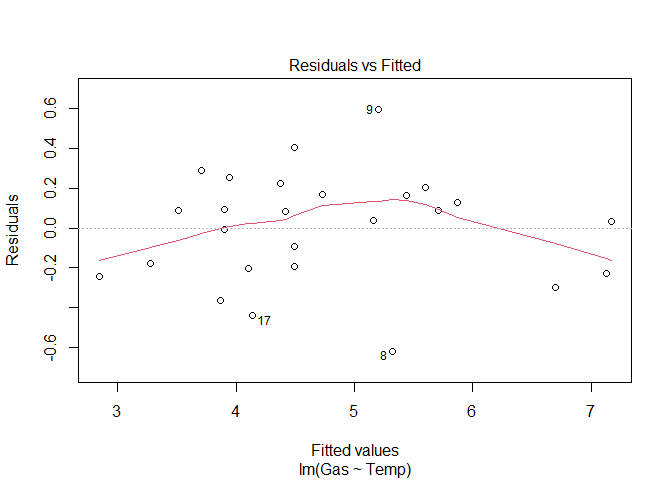

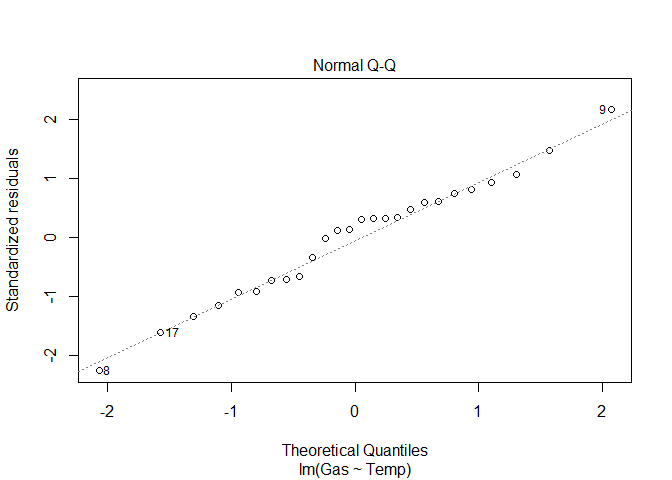

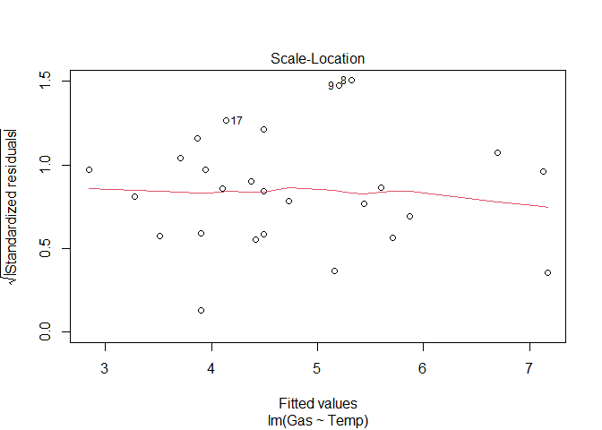

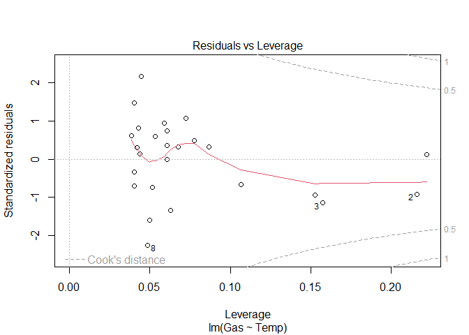

```r
heat_model_old <- lm(Gas ~ Temp, heat[heat$Insulate == "Before",])
plot(heat_model_old)
```

```r
summary(heat_model_old)
```

```
##
## Call:
## lm(formula = Gas ~ Temp, data = heat[heat$Insulate == "Before",
##     ])
##
## Residuals:
##      Min       1Q   Median       3Q      Max
## -0.62020 -0.19947  0.06068  0.16770  0.59778
##
## Coefficients:
##             Estimate Std. Error t value Pr(>|t|)
## (Intercept)  6.85383    0.11842   57.88   <2e-16 ***
## Temp        -0.39324    0.01959  -20.08   <2e-16 ***
## ---
## Signif. codes:  0 '***' 0.001 '**' 0.01 '*' 0.05 '.' 0.1 ' ' 1
##
## Residual standard error: 0.2813 on 24 degrees of freedom
## Multiple R-squared:  0.9438, Adjusted R-squared:  0.9415
## F-statistic: 403.1 on 1 and 24 DF,  p-value: < 2.2e-16
```

```r
Anova(heat_model_old, type = "III")
```

```
## Anova Table (Type III tests)
##
## Response: Gas
##              Sum Sq Df F value    Pr(>F)
## (Intercept) 265.115  1 3349.59 < 2.2e-16 ***
## Temp         31.905  1  403.11 < 2.2e-16 ***
## Residuals     1.900 24
## ---
## Signif. codes:  0 '***' 0.001 '**' 0.01 '*' 0.05 '.' 0.1 ' ' 1
```

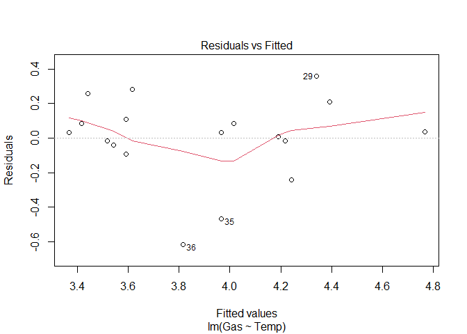

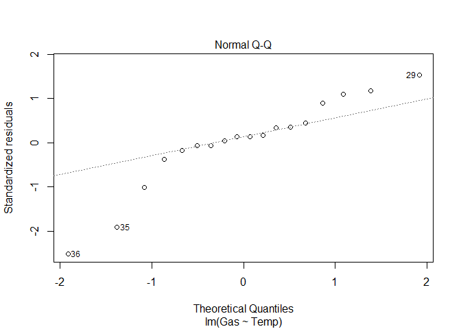

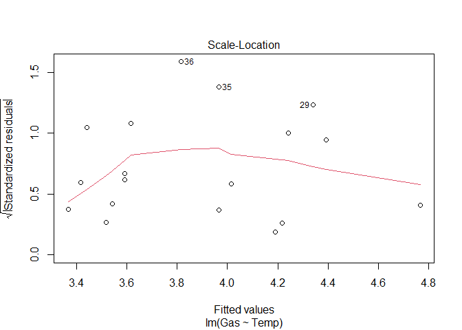

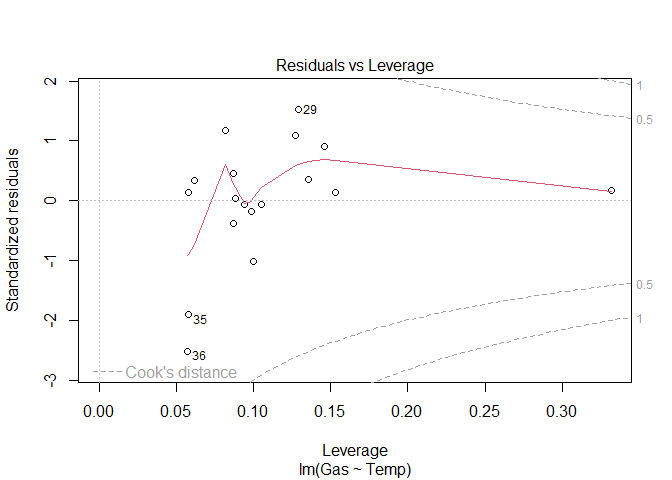

```r
heat_model_new<- lm(Gas ~ Temp, heat[heat$Insulate == "After",])
plot(heat_model_new)
```

```r
summary(heat_model_new)
```

```
##
## Call:
## lm(formula = Gas ~ Temp, data = heat[heat$Insulate == "After",
##     ])
##
## Residuals:
##      Min       1Q   Median       3Q      Max
## -0.61677 -0.03594  0.03300  0.10180  0.35901
##
## Coefficients:
##             Estimate Std. Error t value Pr(>|t|)
## (Intercept)  4.59062    0.12145  37.799  < 2e-16 ***
## Temp        -0.24963    0.03769  -6.623 5.86e-06 ***
## ---
## Signif. codes:  0 '***' 0.001 '**' 0.01 '*' 0.05 '.' 0.1 ' ' 1
##
## Residual standard error: 0.2519 on 16 degrees of freedom
## Multiple R-squared:  0.7327, Adjusted R-squared:  0.716
## F-statistic: 43.87 on 1 and 16 DF,  p-value: 5.857e-06
```

```r
Anova(heat_model_new, type = "III")
```

```
## Anova Table (Type III tests)
##
## Response: Gas
##             Sum Sq Df  F value    Pr(>F)
## (Intercept) 90.636  1 1428.759 < 2.2e-16 ***
## Temp         2.783  1   43.867 5.857e-06 ***
## Residuals    1.015 16
## ---
## Signif. codes:  0 '***' 0.001 '**' 0.01 '*' 0.05 '.' 0.1 ' ' 1
```

*There is a significant relationship between gas usage and temperature for old and new insulation homes. However, the old insulation led to using 400 ft<sup>3</sup> more gas per week to heat the house with every degree drop in temperature, while the new insulation leads to a increase of only 250 ft<sup>3</sup> more gas per week with each degree drop.*

###3

3. Data on the height, diameter, and volume of cherry trees was collected for use in developing an optimal model to predict timber volume. Data is available @

http://www.statsci.org/data/general/cherry.txt